# Most Popular Vehicles

Riley Zamora

2023-09-27

# Abstract

The goal of this analysis is to represent which vehicles are most prominent in the data.

# Load in data & Libraries

## Libraries

```r
library(tidyverse)
library(ggplot2)
library(kableExtra)
library(lubridate)
```

## Data

```r
data <- read.csv("20230921 appraisal activity.csv")
```

# Data Wrangle

## Removing NA’s

```r
data <- na.omit(data)
```

## Which Vars are Required

```r
colnames(data)
```

```
##  [1] "create_date"             "vin"
##  [3] "odometer"                "dealer_id"
##  [5] "dealer_name"             "dealer_contact_province"
##  [7] "dealer_contact_postal"   "country"
##  [9] "source_type"             "ph_year"
## [11] "ph_manuf"                "ph_model"
## [13] "ph_body"                 "ph_engtype"
## [15] "trade"                   "market"
## [17] "source"
```

`create_date`: could be useful if we want to see most popular vehicles by month  
`vin`: not immediately useful might add back later  
`odometer`: could be interesting to see what mileage range shows up most often  
`dealer_id`, `dealer_name`, etc.: not immediately useful. Performing a different analysis on dealer info  
`country`: most popular by country could be interesting  
`source_type`: not useful  
`ph_year`: year of vehicle is a major component  
`ph_manuf`: which manufacturers are most common  
`ph_model`: model of vehicle is a major component  
`ph_body`: body type of vehicle is a major component  
`ph_engtype`: type of motor is a major component  
`trade`: not useful  
`market`: not useful  
`source`: not useful

## Select Vars needed

```r
vehicles <- data |>
  select(create_date, odometer, country,
         ph_year, ph_manuf, ph_model,
         ph_body, ph_body, ph_engtype)
```

This data frame vehicles will be called back upon to create smaller, more specific frames.

## Check Var Types

```r
sapply(vehicles, class)
```

```
## create_date    odometer     country     ph_year    ph_manuf    ph_model
## "character" "character"   "integer"   "integer" "character" "character"
##     ph_body  ph_engtype
## "character" "character"
```

Factor country. Odometer should be object class numeric. create_date should be object class date. Let’s apply these changes.

Need to account for NULL occurrences in selected columns.

```r
any(vehicles$odometer %in% "NULL")
```

```
## [1] TRUE
```

```r
sum(vehicles$odometer == "NULL")
```

```
## [1] 114
```

I have concluded that there are only NULL vales in odometer column. We will now replace these with 0 before converting to int.

```r
vehicles <- vehicles |>
  mutate(odometer = ifelse(odometer == "NULL", "0", odometer),
         odometer = as.numeric(odometer),
         country = as.factor(country),
         create_date = as.Date(create_date)
         )
```

```r
sapply(vehicles, class)
```

```
## create_date    odometer     country     ph_year    ph_manuf    ph_model
##      "Date"   "numeric"    "factor"   "integer" "character" "character"
##     ph_body  ph_engtype
## "character" "character"
```

## Group Data to Create Visuals

### Manufacturer

Lets first create a new frame for the manufacturer of the vehicles.

```r
manuf_frame <- vehicles |>
  select(ph_manuf) |>
  group_by(ph_manuf) |>
  summarise(count = n()) |>
  arrange(desc(count))

kable(head(manuf_frame), format = 'html')
```

| ph_manuf | count |
| --- | --- |
| FORD | 275647 |
| TOYOTA | 223603 |
| CHEV | 212136 |
| HONDA | 161787 |
| JEEP | 108484 |
| NISSAN | 106487 |

Now we can represent which manufacturers have been the most commonly input.

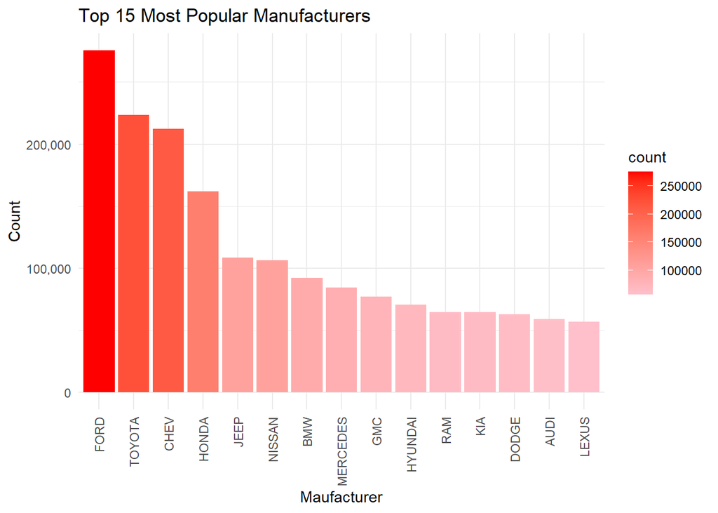

```r
manuf_plot1 <- manuf_frame[1:15,] |>
  ggplot(aes(x = reorder(ph_manuf, -count),
             y = count,
             fill = count)) +
  geom_bar(stat = "identity") +
  scale_fill_gradient(low = 'pink', high = 'red') +
  labs(x = 'Maufacturer', y = 'Count', title = 'Top 15 Most Popular Manufacturers') +
  theme_minimal() +
  theme(axis.text.x = element_text(angle = 90, vjust = 0.5, hjust = 1))

manuf_plot1 + scale_y_continuous(labels = scales::comma) # allows us to see the counts better
```

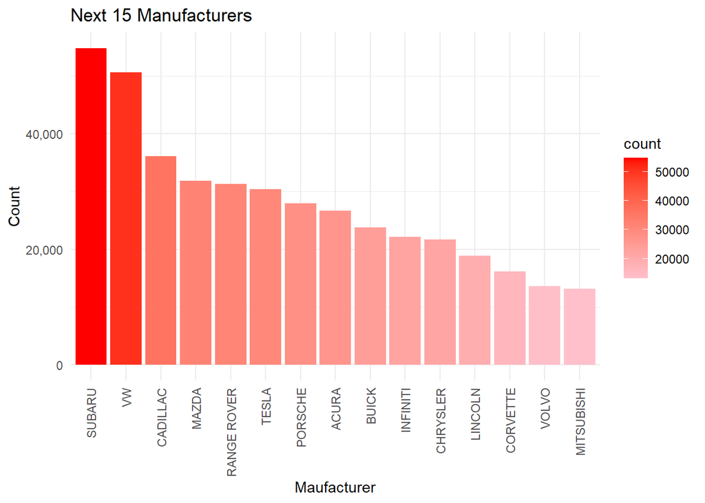

```r
manuf_plot2 <- manuf_frame[16:30,] |>
  ggplot(aes(x = reorder(ph_manuf, -count),
             y = count,
             fill = count)) +
  geom_bar(stat = "identity") +
  scale_fill_gradient(low = 'pink', high = 'red') +
  labs(x = 'Maufacturer', y = 'Count', title = 'Next 15 Manufacturers') +
  theme_minimal() +
  theme(axis.text.x = element_text(angle = 90, vjust = 0.5, hjust = 1))

manuf_plot2 + scale_y_continuous(labels = scales::comma)
```

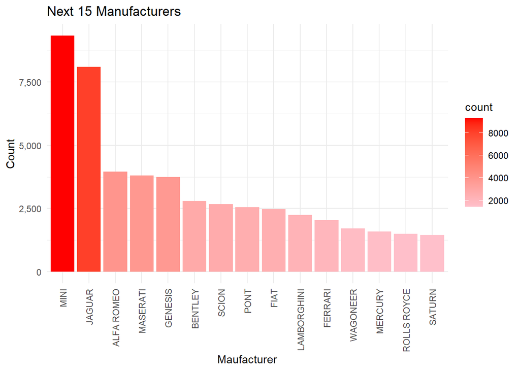

```r
manuf_plot3 <- manuf_frame[31:45,] |>
  ggplot(aes(x = reorder(ph_manuf, -count),
             y = count,
             fill = count)) +
  geom_bar(stat = "identity") +
  scale_fill_gradient(low = 'pink', high = 'red') +
  labs(x = 'Maufacturer', y = 'Count', title = 'Next 15 Manufacturers') +
  theme_minimal() +
  theme(axis.text.x = element_text(angle = 90, vjust = 0.5, hjust = 1))

manuf_plot3 + scale_y_continuous(labels = scales::comma)
```

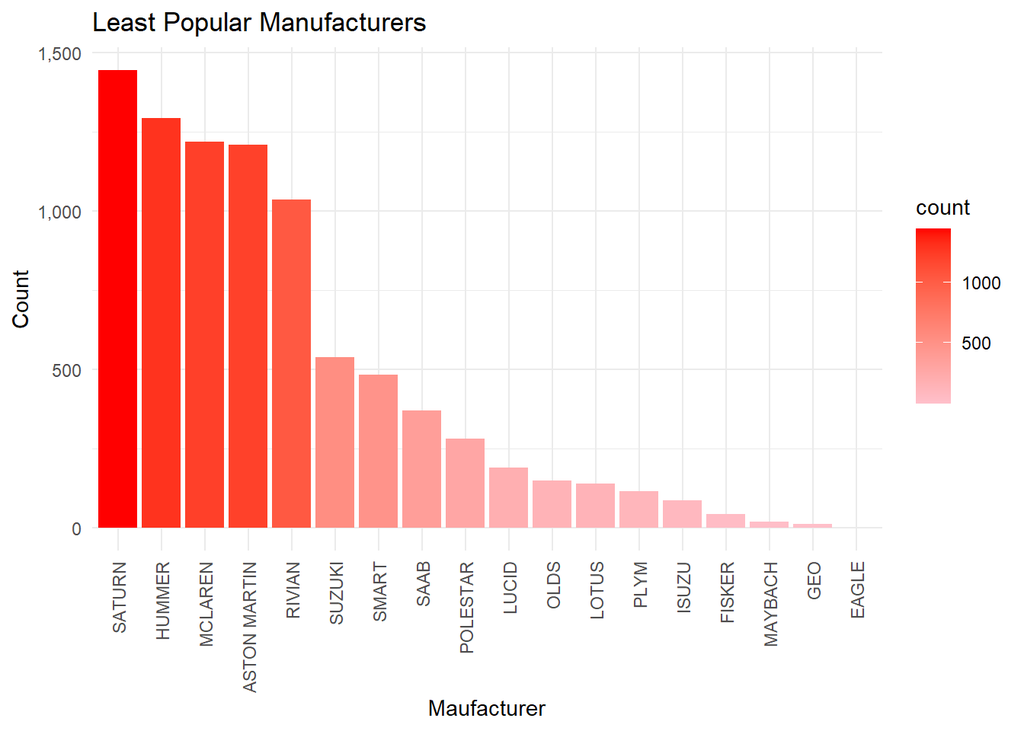

```r
manuf_plot4 <- manuf_frame[45:62,] |>
  ggplot(aes(x = reorder(ph_manuf, -count),
             y = count,
             fill = count)) +
  geom_bar(stat = "identity") +
  scale_fill_gradient(low = 'pink', high = 'red') +
  labs(x = 'Maufacturer', y = 'Count', title = 'Least Popular Manufacturers') +
  theme_minimal() +
  theme(axis.text.x = element_text(angle = 90, vjust = 0.5, hjust = 1))

manuf_plot4 + scale_y_continuous(labels = scales::comma)
```

Ford has a total of 275647 searches, and eagle has 2.

### Model

```r
model_frame <- vehicles |>
  select(ph_model) |>
  group_by(ph_model) |>
  summarise(count = n()) |>
  arrange(desc(count))

kable(head(model_frame), format = 'html')
```

| ph_model | count |
| --- | --- |
| F150 XLT SUPERCREW CAB | 22557 |
| EQUINOX LT | 14257 |
| ESCAPE SE | 13787 |
| EXPLORER XLT | 12933 |
| CIVIC LX | 12821 |
| F150 LARIAT SUPERCREW CAB | 12341 |

Since this data frame is so large, we will show the top 25 models. Then, we will randomly sample the frame to gain some insight on how certain models compare to others.

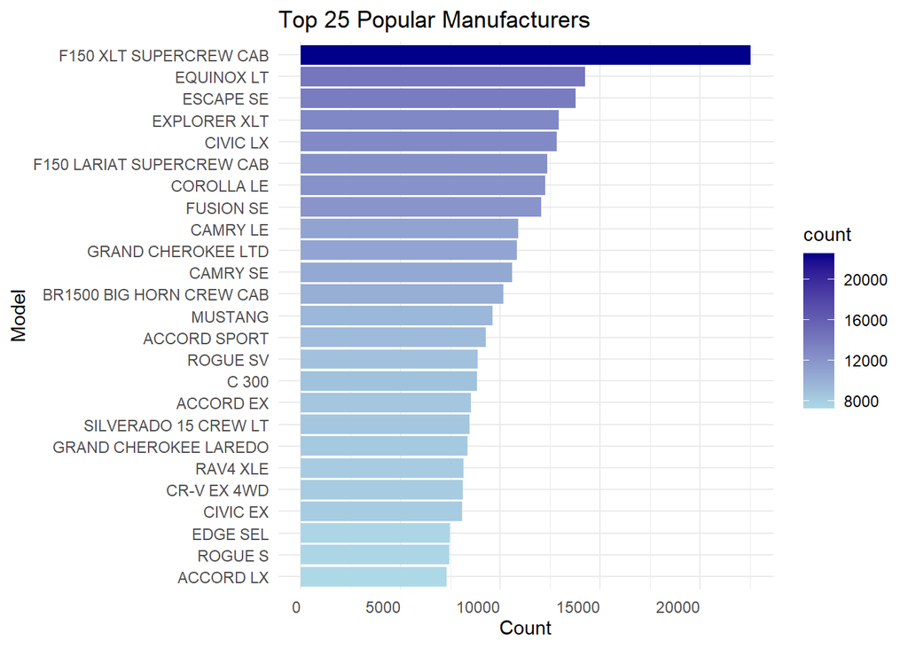

```r
model_plot1 <- model_frame[1:25,] |>
  ggplot(aes(x = reorder(ph_model, count),
             y = count,
             fill = count)) +
  geom_bar(stat = "identity") +
  scale_fill_gradient(low = 'lightblue', high = 'darkblue') +
  labs(x = 'Model', y = 'Count', title = 'Top 25 Popular Manufacturers') +
  theme_minimal() +
  theme(axis.text.x = element_text(angle = 0, vjust = 0.5, hjust = 1)) +
  coord_flip()

model_plot1
```

Now to randomly sample 1000 of these vehicles. Then, display top 25 randomly sampled.

```r
model_sample <- model_frame |>
  sample_n(1000) |>
  arrange(desc(count))
```

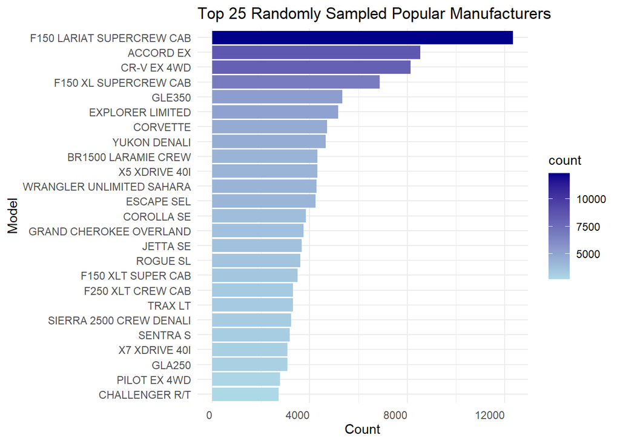

```r
model_sample_plot <- model_sample[1:25,] |>
  ggplot(aes(x = reorder(ph_model, count),
             y = count,
             fill = count)) +
  geom_bar(stat = "identity") +
  scale_fill_gradient(low = 'lightblue', high = 'darkblue') +
  labs(x = 'Model', y = 'Count',
       title = 'Top 25 Randomly Sampled Popular Manufacturers') +
  theme_minimal() +
  theme(axis.text.x = element_text(angle = 0, vjust = 0.5, hjust = 1)) +
  coord_flip()

model_sample_plot
```

### Body

```r
body_frame <- vehicles |>
  select(ph_body) |>
  group_by(ph_body) |>
  summarise(count = n()) |>
  arrange(desc(count))

kable(head(body_frame), format = 'html')
```

| ph_body | count |
| --- | --- |
| 4 DOOR SUV | 897027 |
| 4 DOOR SEDAN | 526868 |
| 4 DOOR P/UP | 322977 |
| COUPE | 108903 |
| 4 DOOR HATCHBACK | 49383 |
| CONVERTIBLE | 43354 |

4 door SUV’s are by far the most popular body type. This could be expected because people like to have passengers. There is such a large difference between the top cars and the rest so we will split up the plots a bit different.

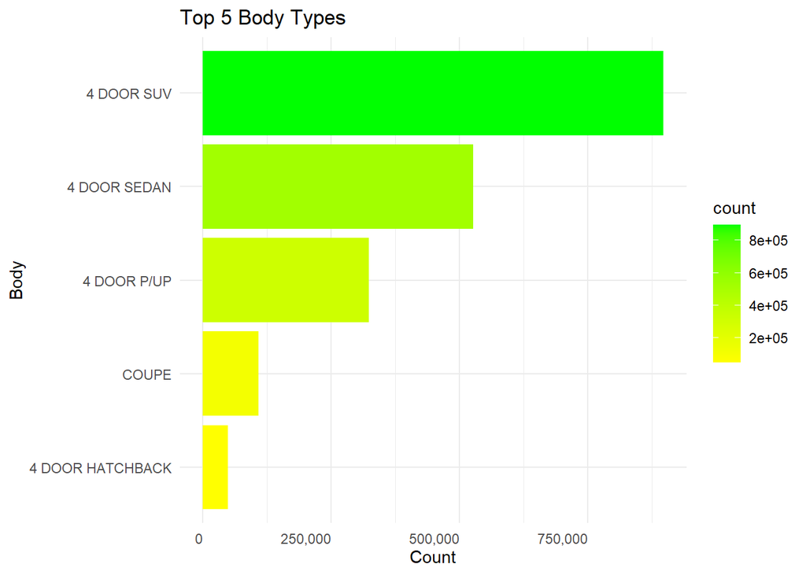

```r
body_plot1 <- body_frame[1:5,] |>
  ggplot(aes(x = reorder(ph_body, count),
             y = count,
             fill = count)) +
  geom_bar(stat = "identity") +
  scale_fill_gradient(low = 'yellow', high = 'green') +
  labs(x = 'Body', y = 'Count',
       title = 'Top 5 Body Types') +
  theme_minimal() +
  theme(axis.text.x = element_text(angle = 0, vjust = 0.5, hjust = 1)) +
  coord_flip()

body_plot1 +
  scale_y_continuous(labels = scales::comma)
```

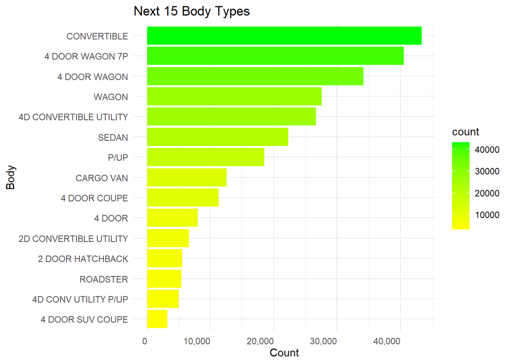

```r
body_plot2 <- body_frame[6:20,] |>
  ggplot(aes(x = reorder(ph_body, count),
             y = count,
             fill = count)) +
  geom_bar(stat = "identity") +
  scale_fill_gradient(low = 'yellow', high = 'green') +
  labs(x = 'Body', y = 'Count',
       title = 'Next 15 Body Types') +
  theme_minimal() +
  theme(axis.text.x = element_text(angle = 0, vjust = 0.5, hjust = 1)) +
  coord_flip()

body_plot2 +
  scale_y_continuous(labels = scales::comma)
```

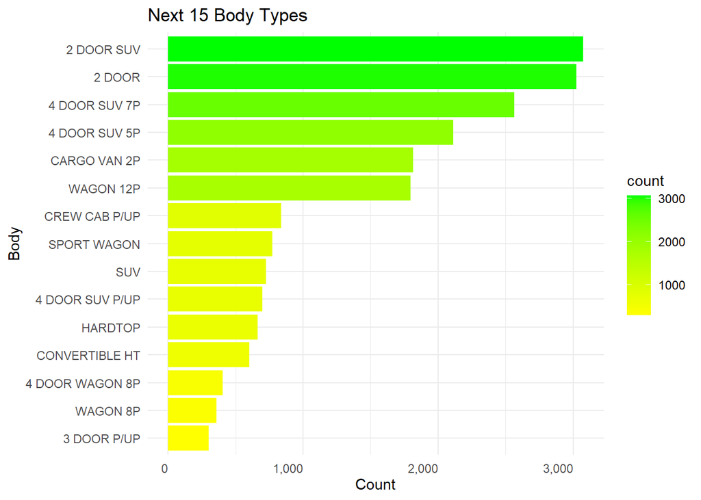

```r
body_plot3 <- body_frame[21:35,] |>
  ggplot(aes(x = reorder(ph_body, count),
             y = count,
             fill = count)) +
  geom_bar(stat = "identity") +
  scale_fill_gradient(low = 'yellow', high = 'green') +
  labs(x = 'Body', y = 'Count',
       title = 'Next 15 Body Types') +
  theme_minimal() +
  theme(axis.text.x = element_text(angle = 0, vjust = 0.5, hjust = 1)) +
  coord_flip()

body_plot3 +
  scale_y_continuous(labels = scales::comma)
```

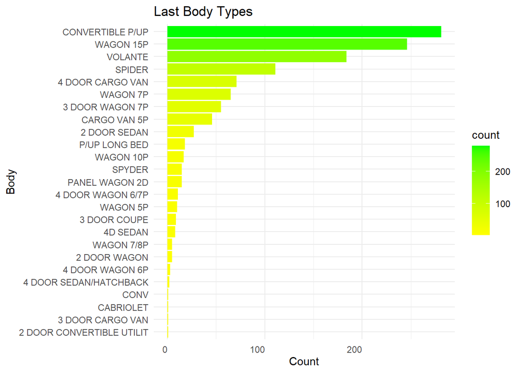

```r
body_plot4 <- body_frame[36:60,] |>
  ggplot(aes(x = reorder(ph_body, count),
             y = count,
             fill = count)) +
  geom_bar(stat = "identity") +
  scale_fill_gradient(low = 'yellow', high = 'green') +
  labs(x = 'Body', y = 'Count',
       title = 'Last Body Types') +
  theme_minimal() +
  theme(axis.text.x = element_text(angle = 0, vjust = 0.5, hjust = 1)) +
  coord_flip()

body_plot4 +
  scale_y_continuous(labels = scales::comma)
```

Notice that “4D Sedan” represents a “4 Door Sedan”. This is a discrepancy in the data. There is also a label, “4 Door”, which could be anything. This could be due to the manufacturer.

### Engine Type

```r
eng_frame <- vehicles |>
  select(ph_engtype) |>
  group_by(ph_engtype) |>
  summarise(count = n()) |>
  arrange(desc(count))

kable(head(eng_frame), format = 'html')
```

| ph_engtype | count |
| --- | --- |
| 3.5L V6 | 196485 |
| 2.0L 4 CYL TURBO | 187931 |
| 3.6L V6 | 177752 |
| 2.5L 4 CYL | 160977 |
| 2.4L 4 CYL | 134217 |
| 2.0L 4 CYL | 103650 |

There are 359 different engtypes. Lets just look at the top 25, split into groupings that are readable.

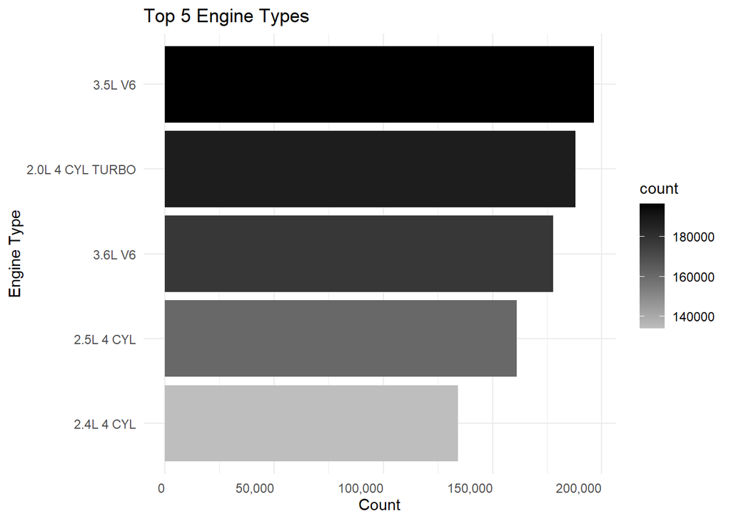

```r
eng_plot <- eng_frame[1:5,] |>
  ggplot(aes(x = reorder(ph_engtype, count),
             y = count,
             fill = count)) +
  geom_bar(stat = "identity") +
  scale_fill_gradient(low = 'grey', high = 'black') +
  labs(x = 'Engine Type', y = 'Count',
       title = 'Top 5 Engine Types') +
  theme_minimal() +
  theme(axis.text.x = element_text(angle = 0, vjust = 0.5, hjust = 1)) +
  coord_flip()

eng_plot +
  scale_y_continuous(labels = scales::comma)
```

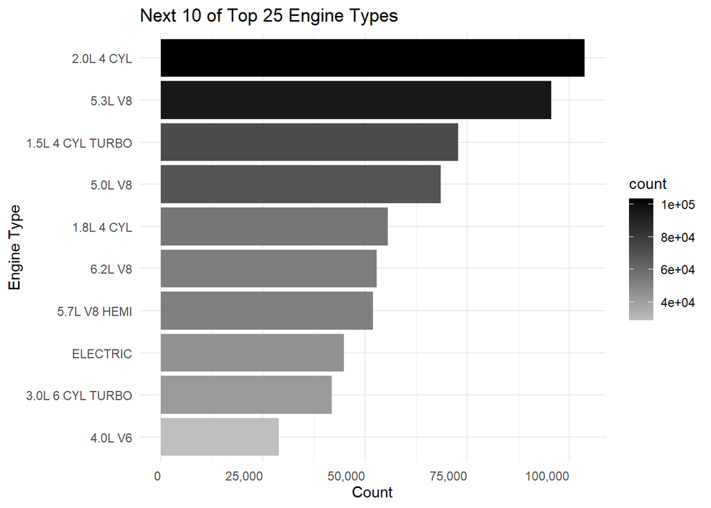

```r
eng_plot2 <- eng_frame[6:15,] |>
  ggplot(aes(x = reorder(ph_engtype, count),
             y = count,
             fill = count)) +
  geom_bar(stat = "identity") +
  scale_fill_gradient(low = 'grey', high = 'black') +
  labs(x = 'Engine Type', y = 'Count',
       title = 'Next 10 of Top 25 Engine Types') +
  theme_minimal() +
  theme(axis.text.x = element_text(angle = 0, vjust = 0.5, hjust = 1)) +
  coord_flip()

eng_plot2 +
  scale_y_continuous(labels = scales::comma)
```

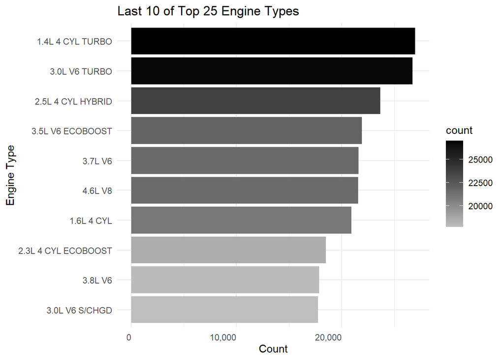

```r
eng_plot3 <- eng_frame[16:25,] |>
  ggplot(aes(x = reorder(ph_engtype, count),
             y = count,
             fill = count)) +
  geom_bar(stat = "identity") +
  scale_fill_gradient(low = 'grey', high = 'black') +
  labs(x = 'Engine Type', y = 'Count',
       title = 'Last 10 of Top 25 Engine Types') +
  theme_minimal() +
  theme(axis.text.x = element_text(angle = 0, vjust = 0.5, hjust = 1)) +
  coord_flip()

eng_plot3 +
  scale_y_continuous(labels = scales::comma)
```

### Year

```r
year_frame <- vehicles |>
  select(ph_year) |>
  group_by(ph_year) |>
  summarise(count = n()) |>
  arrange(desc(count))

kable(head(year_frame), format = 'html')
```

| ph_year | count |
| --- | --- |
| 2020 | 277881 |
| 2021 | 235923 |
| 2019 | 219920 |
| 2022 | 201972 |
| 2018 | 176281 |
| 2017 | 161327 |

We will display all entries because there are 34 of them. Notice that everything seems to go in order of year excpet in a few places.

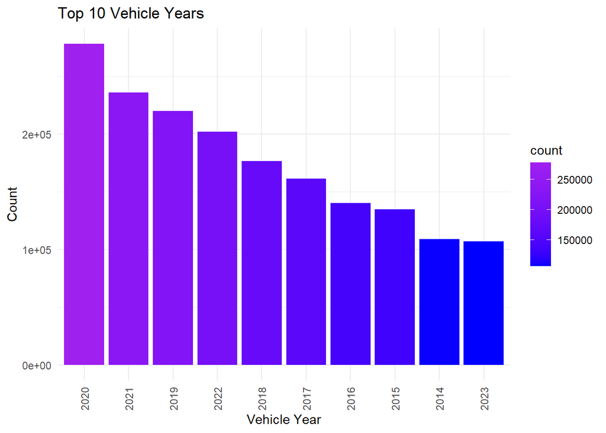

```r
year_plot1 <- year_frame[1:10, ] |>
  ggplot(aes(x = reorder(ph_year, -count),
             y = count,
             fill = count)) +
  geom_bar(stat = "identity") +
  scale_fill_gradient(low = 'blue', high = 'purple') +
  labs(x = 'Vehicle Year', y = 'Count',
       title = 'Top 10 Vehicle Years') +
  theme_minimal() +
  theme(axis.text.x = element_text(angle = 90, vjust = 0.5, hjust = 1))

year_plot1
```

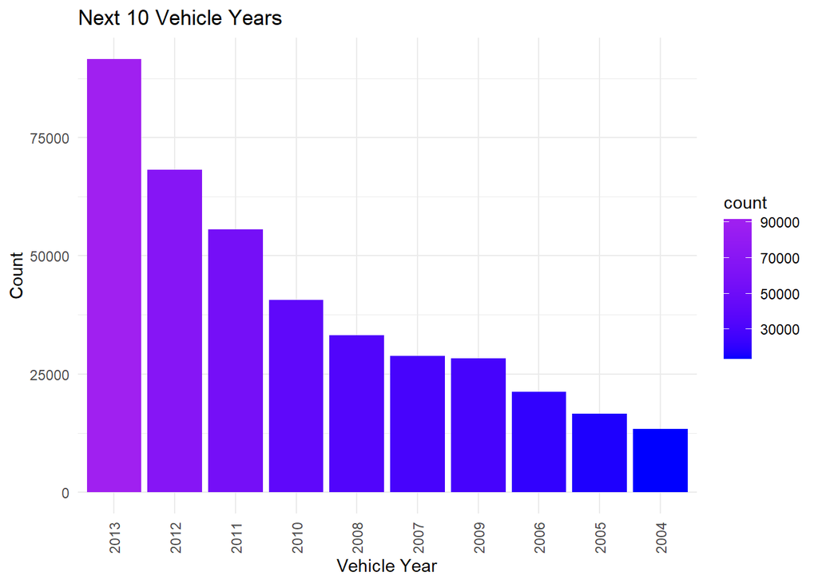

```r
year_plot2 <- year_frame[11:20, ] |>
  ggplot(aes(x = reorder(ph_year, -count),
             y = count,
             fill = count)) +
  geom_bar(stat = "identity") +
  scale_fill_gradient(low = 'blue', high = 'purple') +
  labs(x = 'Vehicle Year', y = 'Count',
       title = 'Next 10 Vehicle Years') +
  theme_minimal() +
  theme(axis.text.x = element_text(angle = 90, vjust = 0.5, hjust = 1))

year_plot2
```

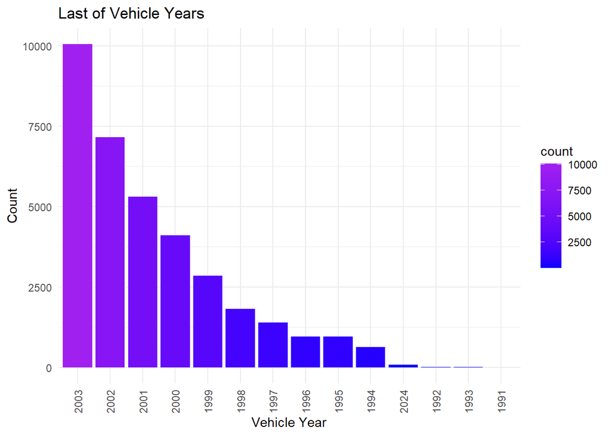

```r
year_plot3 <- year_frame[21:34, ] |>
  ggplot(aes(x = reorder(ph_year, -count),
             y = count,
             fill = count)) +
  geom_bar(stat = "identity") +
  scale_fill_gradient(low = 'blue', high = 'purple') +
  labs(x = 'Vehicle Year', y = 'Count',
       title = 'Last of Vehicle Years') +
  theme_minimal() +
  theme(axis.text.x = element_text(angle = 90, vjust = 0.5, hjust = 1))

year_plot3
```

Notice first that 2020 is the top year selected with 2021 in second. 2022 is below 2019 and 2023 is below 2014. I am sure this is due to time spent on the market. However, looking at 2009 we see that it is below 2008 and 2007. This could be do to a decrease of cars being manufactured in the recession or a new generation of cars that were disliked by consumers. Also notice that 2024 is down with the 1990’s. I am sure this is due to lack of production and time spent on the market.

### Odometer

To look at the odometer popularity, we will need to cohort them into increments of 15,000 miles. Then we will be able to view what ranges of miles are being searched for the most often. However, there are some discrepancies within the data that need attention. First of all, some vehicles has misentered odometer readings.

```r
# create base frame for odometer
odo_frame <- vehicles |>
  select(odometer)
```

Now lets see what the max and min values are.

```r
max(odo_frame$odometer)
```

```
## [1] 1e+10
```

Now that’s a lot of miles. Let’s do the same for min miles.

```r
min(odo_frame$odometer)
```

```
## [1] -514
```

Hmmm.

We have already adjusted for NULL entries to be 0 so we will adjust for that as well. I believe there were 114 NULL occurrences.

```r
odo_frame |>
  filter(odometer == 0) |>
  nrow()
```

```
## [1] 1108
```

There are 1108 values for 0. Since this is a reasonable size, keep in mind 114 of them are NULL and the others may be unknown before.

Let’s see how many vehicles have more than say 500,000 miles.

```r
odo_frame |>
  filter(odometer > 500000) |>
  nrow()
```

```
## [1] 818
```

For these 818, we will simply remove them. We will also create our cohorts of 15,000 miles

```r
# remove unwanted inputs
odo_frame <- odo_frame |>
  filter(odometer >= 0 & odometer < 500000) |>
  mutate(cohort = (odometer %/% 15000) * 15000) |>
  mutate(CohortLabel = case_when(
    cohort == 0 ~ "0 to 15,000",
    cohort > 0 ~ paste0(cohort + 1, " to ", cohort + 15000)
  ))
```

Now that we have created our cohorts, we can add in our grouping and counts to see which odometer ranges are the most used.

```r
odo_grouped <- odo_frame |>
  group_by(CohortLabel) |>
  summarise(count = n()) |>
  arrange(desc(count))

kable(head(odo_grouped), format = 'html') |>
  column_spec(2, width = "1.5cm")
```

| CohortLabel | count |
| --- | --- |
| 15001 to 30000 | 315993 |
| 30001 to 45000 | 298594 |
| 0 to 15,000 | 298225 |
| 45001 to 60000 | 229932 |
| 60001 to 75000 | 205338 |
| 75001 to 90000 | 176824 |

As you can expect the higher the miles the less searches they show up in. There is some variation to this in the first few rows. I chose not to make a visual because it would be pretty boring to look at.

## Putting it together

Let’s combine manufacturer, model, body, and engine type to see what specific vehicles are actually being sought out the most.

```r
combined_frame <- vehicles |>
  select(ph_manuf, ph_model, ph_body, ph_engtype, ph_year) |>
  group_by(ph_manuf, ph_model, ph_body, ph_engtype, ph_year) |>
  summarise(count = n()) |>
  arrange(desc(count))

kable(head(combined_frame), format = 'html')
```

| ph_manuf | ph_model | ph_body | ph_engtype | ph_year | count |
| --- | --- | --- | --- | --- | --- |
| CHEV | EQUINOX LT | 4 DOOR SUV | 1.5L 4 CYL TURBO | 2020 | 4088 |
| FORD | F150 XLT SUPERCREW CAB | 4 DOOR P/UP | 5.0L V8 | 2018 | 3500 |
| FORD | F150 XLT SUPERCREW CAB | 4 DOOR P/UP | 5.0L V8 | 2020 | 3472 |
| FORD | F150 XLT SUPERCREW CAB | 4 DOOR P/UP | 5.0L V8 | 2019 | 3212 |
| FORD | EXPLORER XLT | 4 DOOR SUV | 2.3L 4 CYL ECOBOOST | 2020 | 2963 |
| FORD | ESCAPE SE | 4 DOOR SUV | 1.5L I4 ECOBOOST | 2017 | 2437 |

# Looking at Some Other Aspects

In this section we will do some deeper analysis into the vehicles by country. We will also take a look into the time frames that dealers are looking for different cars. This could be useful to see if there is any seasonality in the data.

## By Country

Let’s split the data into two frames by their country code.

```r
US_vehicles <- vehicles |>
  filter(country == 1)

CA_vehicles <- vehicles |>
  filter(country == 2)
```

Now we can see which vehicles are most popular in each country.

### US

```r
US_top <- US_vehicles |>
  select(ph_manuf, ph_model, ph_body, ph_engtype, ph_year) |>
  group_by(ph_manuf, ph_model, ph_body, ph_engtype, ph_year) |>
  summarise(count = n()) |>
  arrange(desc(count))

kable(head(US_top), format = 'html')
```

| ph_manuf | ph_model | ph_body | ph_engtype | ph_year | count |
| --- | --- | --- | --- | --- | --- |
| CHEV | EQUINOX LT | 4 DOOR SUV | 1.5L 4 CYL TURBO | 2020 | 3976 |
| FORD | EXPLORER XLT | 4 DOOR SUV | 2.3L 4 CYL ECOBOOST | 2020 | 2875 |
| FORD | F150 XLT SUPERCREW CAB | 4 DOOR P/UP | 5.0L V8 | 2018 | 2831 |
| FORD | F150 XLT SUPERCREW CAB | 4 DOOR P/UP | 5.0L V8 | 2020 | 2676 |
| FORD | F150 XLT SUPERCREW CAB | 4 DOOR P/UP | 5.0L V8 | 2019 | 2568 |
| TOYOTA | COROLLA LE | 4 DOOR SEDAN | 1.8L 4 CYL | 2021 | 2426 |

### CA

```r
CA_top <- CA_vehicles |>
  select(ph_manuf, ph_model, ph_body, ph_engtype, ph_year) |>
  group_by(ph_manuf, ph_model, ph_body, ph_engtype, ph_year) |>
  summarise(count = n()) |>
  arrange(desc(count))

kable(head(CA_top), format = 'html')
```

| ph_manuf | ph_model | ph_body | ph_engtype | ph_year | count |
| --- | --- | --- | --- | --- | --- |
| TESLA | MODEL 3 STDRANGE PLUS RWD | SEDAN | ELECTRIC | 2023 | 975 |
| FORD | F150 XLT SUPERCREW CAB | 4 DOOR P/UP | 5.0L V8 | 2020 | 796 |
| FORD | F150 XLT SUPERCREW CAB | 4 DOOR P/UP | 5.0L V8 | 2018 | 669 |
| TESLA | MODEL 3 LONG RANGE RWD | SEDAN | ELECTRIC | 2018 | 663 |
| FORD | F150 XLT SUPERCREW CAB | 4 DOOR P/UP | 5.0L V8 | 2019 | 644 |
| FORD | F150 LARIAT SUPERCREW CAB | 4 DOOR P/UP | 5.0L V8 | 2021 | 604 |

Notice that there is a difference between the top vehicles in US and CA. There is also a difference in top vehicles over all and US/CA. Also, take note that there are only 165558 entries from Canada and about 2 million in the US. Although small, Canada is making an impact on the overall input and top car. Canadians love Teslas.

## By Create Date

To look at this by create date, We will cohort the data entry dates into months. Then, we will be able to see if some cars are more popular in different months.

### Separating into Months

```r
month_frame <- vehicles |>
  select(-odometer, -country) |>
  mutate(month = month(create_date, label = TRUE))
```

### Table for Top 5 Cars Each Month

#### April

```r
Apr_top_vehicles <- month_frame |>
  filter(month == 'Apr') |>
  group_by(ph_manuf, ph_model, ph_body, ph_engtype, ph_year) |>
  summarise(count = n()) |>
  arrange(desc(count))

kable(head(Apr_top_vehicles), format = 'html')
```

| ph_manuf | ph_model | ph_body | ph_engtype | ph_year | count |
| --- | --- | --- | --- | --- | --- |
| CHEV | EQUINOX LT | 4 DOOR SUV | 1.5L 4 CYL TURBO | 2020 | 778 |
| FORD | F150 XLT SUPERCREW CAB | 4 DOOR P/UP | 5.0L V8 | 2020 | 567 |
| FORD | F150 XLT SUPERCREW CAB | 4 DOOR P/UP | 5.0L V8 | 2018 | 542 |
| FORD | EXPLORER XLT | 4 DOOR SUV | 2.3L 4 CYL ECOBOOST | 2020 | 523 |
| FORD | F150 XLT SUPERCREW CAB | 4 DOOR P/UP | 5.0L V8 | 2019 | 520 |
| CHEV | EQUINOX LT | 4 DOOR SUV | 1.5L 4 CYL TURBO | 2019 | 452 |

#### May

```r
May_top_vehicles <- month_frame |>
  filter(month == 'May') |>
  group_by(ph_manuf, ph_model, ph_body, ph_engtype, ph_year) |>
  summarise(count = n()) |>
  arrange(desc(count))

kable(head(May_top_vehicles), format = 'html')
```

| ph_manuf | ph_model | ph_body | ph_engtype | ph_year | count |
| --- | --- | --- | --- | --- | --- |
| CHEV | EQUINOX LT | 4 DOOR SUV | 1.5L 4 CYL TURBO | 2020 | 835 |
| FORD | F150 XLT SUPERCREW CAB | 4 DOOR P/UP | 5.0L V8 | 2020 | 625 |
| FORD | F150 XLT SUPERCREW CAB | 4 DOOR P/UP | 5.0L V8 | 2018 | 600 |
| FORD | F150 XLT SUPERCREW CAB | 4 DOOR P/UP | 5.0L V8 | 2019 | 599 |
| FORD | EXPLORER XLT | 4 DOOR SUV | 2.3L 4 CYL ECOBOOST | 2020 | 521 |
| TOYOTA | COROLLA LE | 4 DOOR SEDAN | 1.8L 4 CYL | 2020 | 447 |

#### June

```r
Jun_top_vehicles <- month_frame |>
  filter(month == 'Jun') |>
  group_by(ph_manuf, ph_model, ph_body, ph_engtype, ph_year) |>
  summarise(count = n()) |>
  arrange(desc(count))

kable(head(Jun_top_vehicles), format = 'html')
```

| ph_manuf | ph_model | ph_body | ph_engtype | ph_year | count |
| --- | --- | --- | --- | --- | --- |
| CHEV | EQUINOX LT | 4 DOOR SUV | 1.5L 4 CYL TURBO | 2020 | 787 |
| FORD | F150 XLT SUPERCREW CAB | 4 DOOR P/UP | 5.0L V8 | 2020 | 661 |
| FORD | F150 XLT SUPERCREW CAB | 4 DOOR P/UP | 5.0L V8 | 2018 | 642 |
| FORD | EXPLORER XLT | 4 DOOR SUV | 2.3L 4 CYL ECOBOOST | 2020 | 537 |
| FORD | F150 XLT SUPERCREW CAB | 4 DOOR P/UP | 5.0L V8 | 2019 | 532 |
| TOYOTA | COROLLA LE | 4 DOOR SEDAN | 1.8L 4 CYL | 2021 | 445 |

#### July

```r
Jul_top_vehicles <- month_frame |>
  filter(month == 'Jul') |>
  group_by(ph_manuf, ph_model, ph_body, ph_engtype, ph_year) |>
  summarise(count = n()) |>
  arrange(desc(count))

kable(head(Jul_top_vehicles), format = 'html')
```

| ph_manuf | ph_model | ph_body | ph_engtype | ph_year | count |
| --- | --- | --- | --- | --- | --- |
| CHEV | EQUINOX LT | 4 DOOR SUV | 1.5L 4 CYL TURBO | 2020 | 628 |
| FORD | F150 XLT SUPERCREW CAB | 4 DOOR P/UP | 5.0L V8 | 2018 | 613 |
| FORD | F150 XLT SUPERCREW CAB | 4 DOOR P/UP | 5.0L V8 | 2019 | 545 |
| FORD | F150 XLT SUPERCREW CAB | 4 DOOR P/UP | 5.0L V8 | 2020 | 519 |
| CHEV | EQUINOX LT | 4 DOOR SUV | 1.5L 4 CYL TURBO | 2019 | 432 |
| FORD | EXPLORER XLT | 4 DOOR SUV | 2.3L 4 CYL ECOBOOST | 2020 | 431 |

#### August

```r
Aug_top_vehicles <- month_frame |>
  filter(month == 'Aug') |>
  group_by(ph_manuf, ph_model, ph_body, ph_engtype, ph_year) |>
  summarise(count = n()) |>
  arrange(desc(count))

kable(head(Aug_top_vehicles), format = 'html')
```

| ph_manuf | ph_model | ph_body | ph_engtype | ph_year | count |
| --- | --- | --- | --- | --- | --- |
| FORD | F150 XLT SUPERCREW CAB | 4 DOOR P/UP | 5.0L V8 | 2020 | 745 |
| FORD | F150 XLT SUPERCREW CAB | 4 DOOR P/UP | 5.0L V8 | 2018 | 667 |
| CHEV | EQUINOX LT | 4 DOOR SUV | 1.5L 4 CYL TURBO | 2020 | 637 |
| FORD | F150 XLT SUPERCREW CAB | 4 DOOR P/UP | 5.0L V8 | 2019 | 635 |
| FORD | EXPLORER XLT | 4 DOOR SUV | 2.3L 4 CYL ECOBOOST | 2020 | 587 |
| FORD | ESCAPE SE | 4 DOOR SUV | 1.5L I4 ECOBOOST | 2017 | 489 |

#### September

```r
Sep_top_vehicles <- month_frame |>
  filter(month == 'Sep') |>
  group_by(ph_manuf, ph_model, ph_body, ph_engtype, ph_year) |>
  summarise(count = n()) |>
  arrange(desc(count))

kable(head(Sep_top_vehicles), format = 'html')
```

| ph_manuf | ph_model | ph_body | ph_engtype | ph_year | count |
| --- | --- | --- | --- | --- | --- |
| FORD | F150 XLT SUPERCREW CAB | 4 DOOR P/UP | 5.0L V8 | 2018 | 436 |
| CHEV | EQUINOX LT | 4 DOOR SUV | 1.5L 4 CYL TURBO | 2020 | 423 |
| FORD | F150 XLT SUPERCREW CAB | 4 DOOR P/UP | 5.0L V8 | 2019 | 381 |
| FORD | EXPLORER XLT | 4 DOOR SUV | 2.3L 4 CYL ECOBOOST | 2020 | 364 |
| FORD | F150 XLT SUPERCREW CAB | 4 DOOR P/UP | 5.0L V8 | 2020 | 355 |
| TOYOTA | COROLLA LE | 4 DOOR SEDAN | 1.8L 4 CYL | 2021 | 336 |